# my title

#### Comparing against the top25 of the article

```r
# Getting the features that are found to be both the most important for our model classification and are present in the most important features of the paper.
coinciding_features <- top_features_names[top_features_names %in% ST5$`Proteins/Metabolites`]
coinciding_features
```

```
##  [1] "P0DJI9" "P02750" "P02748" "P02768" "P51884" "Q14520" "P01011" "P00751"
##  [9] "P0DJI8" "P12259" "Q9UK55" "P02741" "Q96PD5"
```

# Exercise 3

**External prediction on an independent test cohort**

*Using the final Random Forest model trained on the full training cohort, predict disease severity for patients in the independent test cohort provided in Supplementary Table 4.*

*Your task is to:*

- *Apply the trained model to the test cohort.*
- *Obtain predicted probabilities of Severe disease for each patient.*
- *Assign predicted class labels based on these probabilities.*
- *Compare predictions to the true clinical labels.*

*How does the model perform on the independent test cohort?*

#### Getting the metadata for the test patients

```r
# Load and prepare the test cohort metadata
test_metadata <- data.frame(Patient_ID = ST1$`Patient ID a`)
test_metadata$Group <- factor(ST1$`Group d`,
                              levels = c(0, 1, 2, 3),
                              labels = c("Healthy Control", "Non-COVID-19",
                                         "Non-severe", "Severe"))

COVID_test_metadata <- test_metadata[
  ST1$`COVID-19 patients corhort` == "Test 1 (C2)" &
  test_metadata$Group %in% c("Non-severe", "Severe"), ]

nrow(COVID_test_metadata)
```

```
## [1] 10
```

#### Prepare the freature matrix

```r
# We'll follow the same steps as for the training dataset:
# Make into a df
test_matrix <- data.frame(ST4)

# Remove all "Metabolites" rows to leave only the Protein features
test_matrix[1,1] <- '-'
test_matrix[1,2] <- '-'
test_matrix <- test_matrix[test_matrix$Gene.Symbol != "NA", ]
test_matrix_copy <- test_matrix
# Use the column with the Proteins' ID as row names
# test_matrix <- test_matrix_copy[2:nrow(test_matrix_copy),]
rownames(test_matrix_copy) <- test_matrix_copy[,1]
# Remove ID and Gene Symbol columns to keep only patient data
test_data <- test_matrix_copy[, -c(1, 2)]

# Transpose: Patients must be rows for Random Forest
test_data <- as.data.frame(t(test_data))
rownames(test_data) <- test_data[,1]
test_data <- test_data[,2:ncol(test_data)]


# Align the matrix with our filtered COVID metadata:
## Only keep patients present in our training subset
test_features <- test_data[rownames(test_data) %in% COVID_test_metadata$Patient_ID, ]

## Making it so the rownames from the training features match the order in the metadata
test_labels <- COVID_test_metadata[match(rownames(test_features), COVID_test_metadata$Patient_ID), ]
test_labels$Group <- droplevels(test_labels$Group)

sum(rownames(test_features) != test_labels$Patient_ID) # Checking how many rownames and columns DON'T match
```

```
## [1] 0
```

#### Align features

```r
# Adding the genes that are not present in the training dataset
missing_genes <- colnames(train_features_final)[!colnames(train_features_final) %in% colnames(test_features)]

for(gene in missing_genes) {
  # Fill with the median value the model learned during training
  test_features[[gene]] <- median(train_features_final[[gene]], na.rm = TRUE)
}


# Leaving only the genes that were used to train the model
test_features_aligned <- test_features[, colnames(test_features) %in% colnames(train_features_final)]

# Making them match
test_features_aligned <- test_features_aligned[, colnames(train_features_final)]
sum(colnames(train_features_final) != colnames(test_features_aligned))
```

```
## [1] 0
```

#### Inputing missing values

```r
# Checking how many missing values are there
sum(is.na(test_features))
```

```
## [1] 0
```

```r
# test_features_final <- apply(test_features_aligned, 2, function(x) {
#   x[is.na(x)] <- median(x, na.rm = TRUE)
#   return(x)
# })
# test_features_final <- as.data.frame(test_features_final)
```

As there are no missing values, we can proceed without needing to input any data.

#### Generate predictions

```r
# Data frame with the classification of each patient
test_preds <- predict(rf_model, test_features, type = "raw")
# Changing the levels from Non.severe to Non-severe
test_preds <- as.factor(test_preds)
levels(test_preds) <- c("Non-severe", "Severe")

# Probability of a patient being severe
test_probs <- predict(rf_model, test_features, type = "prob")[, "Severe"]
```

#### Show results

```r
# Create the Confusion Matrix
# We use the test_labels$Group as the reference
# test_preds$`Non-severe` <- test_preds$Non.severe
conf_matrix <- confusionMatrix(test_preds, test_labels$Group)
print(conf_matrix)
```

```
## Confusion Matrix and Statistics
##
##             Reference
## Prediction   Non-severe Severe
##   Non-severe          0      0
##   Severe              6      4
##
##                Accuracy : 0.4
##                  95% CI : (0.1216, 0.7376)
##     No Information Rate : 0.6
##     P-Value [Acc > NIR] : 0.94524
##
##                   Kappa : 0
##
##  Mcnemar's Test P-Value : 0.04123
##
##             Sensitivity : 0.0
##             Specificity : 1.0
##          Pos Pred Value : NaN
##          Neg Pred Value : 0.4
##              Prevalence : 0.6
##          Detection Rate : 0.0
##    Detection Prevalence : 0.0
##       Balanced Accuracy : 0.5
##
##        'Positive' Class : Non-severe
##
```

```r
# Calculate and Plot ROC/AUC
test_roc <- roc(test_labels$Group, test_probs)
print(paste("Test AUC:", round(auc(test_roc), 4)))
```

```
## [1] "Test AUC: 0.75"
```

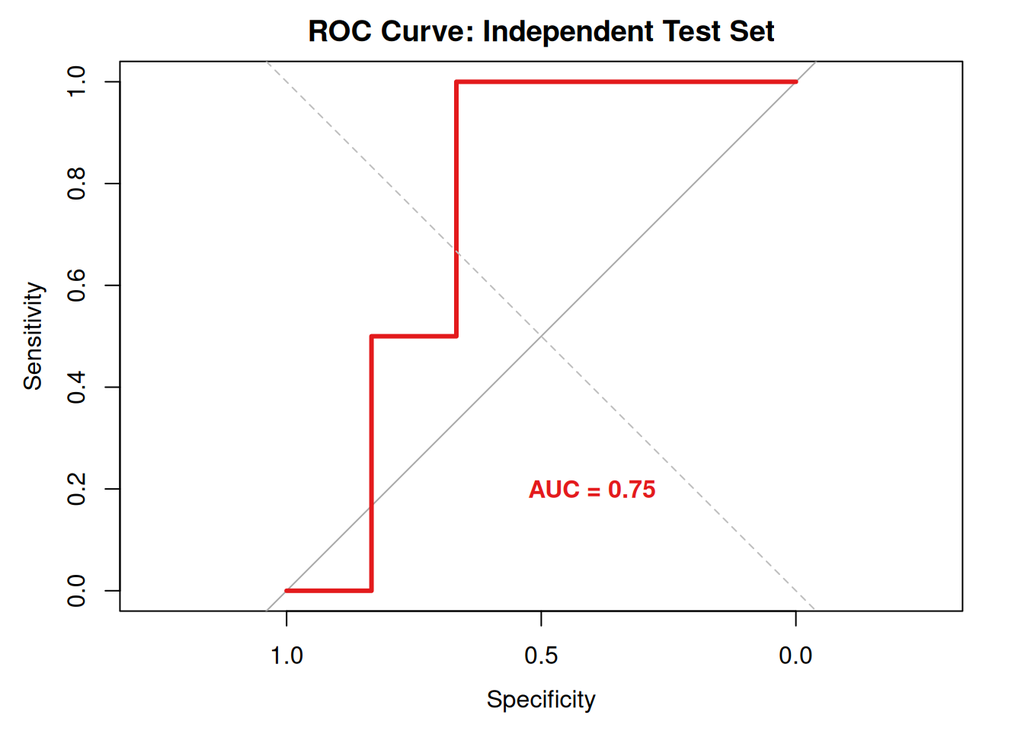

```r
plot(test_roc, col = "#e31a1c", lwd = 3, main = "ROC Curve: Independent Test Set")
abline(a = 0, b = 1, lty = 2, col = "gray")
text(0.4, 0.2, paste("AUC =", round(auc(test_roc), 3)), col = "#e31a1c", font = 2)
```

```r
class(test_preds)
```

```
## [1] "factor"
```

# session info

R version 4.3.3 (2024-02-29) Platform: x86_64-pc-linux-gnu (64-bit) Running under: Ubuntu 24.04.4 LTS

Matrix products: default BLAS: /usr/lib/x86_64-linux-gnu/blas/libblas.so.3.12.0 LAPACK: /usr/lib/x86_64-linux-gnu/lapack/liblapack.so.3.12.0

locale: [1] LC_CTYPE=en_US.UTF-8 LC_NUMERIC=C  
[3] LC_TIME=en_US.UTF-8 LC_COLLATE=en_US.UTF-8  
[5] LC_MONETARY=en_US.UTF-8 LC_MESSAGES=en_US.UTF-8  
[7] LC_PAPER=en_US.UTF-8 LC_NAME=C  
[9] LC_ADDRESS=C LC_TELEPHONE=C  
[11] LC_MEASUREMENT=en_US.UTF-8 LC_IDENTIFICATION=C

time zone: Europe/Madrid tzcode source: system (glibc)

attached base packages: [1] stats graphics grDevices utils datasets methods base

other attached packages: [1] caret_7.0-1 lattice_0.22-5 pheatmap_1.0.13  
[4] dplyr_1.2.0 ggplot2_4.0.2 pROC_1.19.0.1  
[7] readxl_1.4.5 randomForest_4.7-1.2 mice_3.19.0